# Lecture 3: Measures of Dispersion

Tom Hanna

tlhanna@central.uh.edu

University of Houston

2026-04-18

## Last class

- Measures of Central Tendency

  ```
    - Mean
    - Median
    - Mode
  ```

- These tell us about the center of the data
- They help us start to the visualize the data based on the typical or average value

## Today

- Measures of Dispersion (Variation or Spread)

  ```
    - Variance
    - Standard Deviation
    - Range
    - Quartiles
  ```

## We start with the mean

- Start with the mean
- Our variable X: 1,7,21,13,19,5,9,17,11
- Mean is 11.44

## Visualizing distances from the mean

- Plot the data points

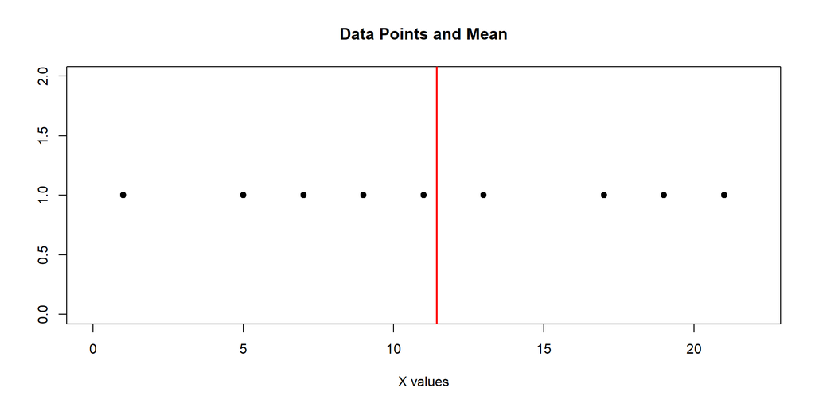

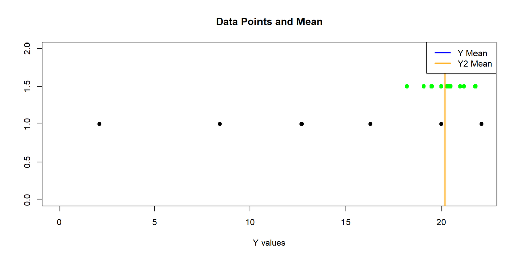

## Drawing on the board time!

```r
# Create a blank grid with both x and y axes numbered 0 to 20 and
# labeled
plot(0, 0, xlim = c(0, 20), ylim = c(0, 15), xlab = "Value", ylab = "",
    main = "Data Points and Mean", xaxt = "n", yaxt = "n")  # Create blank plot
axis(1, at = seq(0, 20, by = 1))  # Add x-axis with ticks from 0 to 20
# add ticks and labels for y axis
axis(2, at = seq(0, 15, by = 1), labels = rep("", 16))  # Add y-axis with ticks from 0 to 15 without labels
# label the y axis ticks at 5, 10, and 15
mtext(c("5", "10", "15"), side = 2, at = c(5, 10, 15), line = 0.5)  # Label y-axis ticks at 5, 10, and 15
```

[output not shown]

## Drawing on the board time!

```r
# Create a blank grid with both x and y axes numbered 0 to 20 and
# labeled
plot(0, 0, xlim = c(0, 20), ylim = c(0, 15), xlab = "Value", ylab = "",
    main = "Data Points and Mean", xaxt = "n", yaxt = "n")  # Create blank plot
axis(1, at = seq(0, 20, by = 1))  # Add x-axis with ticks from 0 to 20
# add ticks and labels for y axis
axis(2, at = seq(0, 15, by = 1), labels = rep("", 16))  # Add y-axis with ticks from 0 to 15 without labels
# label the y axis ticks at 5, 10, and 15
mtext(c("5", "10", "15"), side = 2, at = c(5, 10, 15), line = 0.5)  # Label y-axis ticks at 5, 10, and 15
```

[output not shown]

## Problem with sum of distances

The problem is that because of the definition of mean, the positive lines will cancel out the negative and the dispersion or variation would always be zero!

## Simple Data Example

Suppose we had a very simple data set with only two observations - 5 and 15. The mean is 10. One is 5 above the mean and one is 5 below the mean.

## Distance from Mean Total

So, we want our new measure *total_variation* to equal the sum of the distances.

## Math to the rescure!

**Math comes to the rescue!**

- What is something we can do that turns a negative number into a positive number every time and leaves a positive number as a positive?
- It’s also important that any effect it has on the actual size of the numbers is consistent between positive and negative numbers.

## Math to the rescure! Code

- We can square the distances

## Are we done?

- Suppose we had 1000 observations
- Mean still 10
- Each still 5 points away on average
- What would our total variation be?

Given that the actual average distances is exactly the same for both groups, does that make sense? Is it useful?

## Solution: Average Squared Difference - Variance

- We want the average of the distances or
- Average of the squared differences.
- So our measure of *variance* is in the simplest form:

$$s^2 = \frac{1}{n-1} \sum_{i=1}^{n} (x_i - \bar{x})^2$$

## Variance formula

$$s^2 = \frac{1}{n-1} \sum_{i=1}^{n} (x_i - \bar{x})^2$$

s^2 = variance n = number of observations xi = each observation x̄ = mean of the observations

## Solution

How can we solve this?

- To partially account for this we can take the square root of the variance
- That gives us our next measure: *standard deviation*

## Standard deviation

- *standard deviation* is the square root of the variance

$$s = \sqrt{s^2}$$

## Standard deviation: full formula

$$s = \sqrt{\frac{1}{n-1} \sum_{i=1}^{n} (x_i - \bar{x})^2}$$

## Sample vs Population

- When we have data for the entire population, we can compute the true variance and standard deviation directly, so we divide by n
- When we only have a sample, this is *systematically too small*, underestimating the population spread.
- Dividing by *n−1* **(Bessel’s correction)** adjusts for this and makes the sample variance an unbiased estimator of the population variance

## Population Variance

$$\sigma^2 = \frac{1}{n} \sum_{i=1}^{n} (x_i - \mu)^2$$

## Population Standard Deviation

$$\sigma = \sqrt{\frac{1}{n} \sum_{i=1}^{
n} (x_i - \mu)^2}$$

or

$$\sigma = \sqrt{\sigma^2}$$

## Quartiles

- Quartiles divide the data into four equal parts
- The first quartile (Q1) is the 25th percentile
- The second quartile (Q2) is the 50th percentile (the median)
- The third quartile (Q3) is the 75th percentile
- The interquartile range (IQR) is the difference between Q3 and Q1 (IQR = Q3 - Q1)

## Range

- The range is the difference between the maximum and minimum values in the data set
- Range = Max - Min

## Authorship and License

- Author: Tom Hanna
- Website: [tomhanna.me](https://tom-hanna.org/)
- License: This work is licensed under a [Creative Commons Attribution-NonCommercial-ShareAlike 4.0 International License.](http://creativecommons.org/licenses/by-nc-sa/4.0/)